# Teaching Marketing Analytics: A Pricing Exercise for Quantitative and Substantive Marketing Skills

Authors anonymized for peer review

Your B2B firm sells an energy-efficient heater fan and has divided the country into 100 comparable sales territories, each staffed exclusively by a female sales representative. The sales representatives differ according to their professional experience (measured by the number of years they have been in sales) and whether they have an engineering degree.

The management recently stated that 50% of the sales representatives have at least five years of professional experience in sales, and at least one-third of the sales representatives also have an engineering degree.

The firm’s management randomly varied the prices across the sales territories.

In addition, the management commissioned an advertising agency to support the sales representatives through marketing and provided a dedicated budget. The agency should use this marketing budget for telephone marketing and social media marketing, with an approximately equal allocation towards the two channels (i.e., 50% phone calls and 50% social media marketing). So far, the firm’s management has randomly varied the agency’s budget across the sales territories.

The variable cost per unit of a heater fan is $200.

In the file `data_sales.csv`, you receive information that helps you answer the questions. The data set includes 100 rows, each describing one of the 100 sales territories with the following variables:

Table 1: Description of the Data Set `data_sales.csv`

| Variable | Description |
| --- | --- |
| `quantity` | Number of sold heater fans in the respective sales territory. |
| `price` | Price of the heater fan sold in the respective sales territory. |
| `experience` | Number of years the sales representative has been working in sales. |
| `engineer` | Binary variable indicating whether the sales representative has an engineering degree (= 1) or not (= 0). |
| `gender` | Gender of the sales representative, female (= 1) or other (= 0). |
| `location` | Number of letters of the sales representative’s birthplace (e.g., 7 if the birthplace is “Chicago”). |
| `budget_agency` | Budget used by the advertising agency, which is either spent for phone or social media marketing, in $. |
| `budget_phone` | Budget used for telephone marketing, in $. |
| `b udget_social_media` | Budget used for social media marketing, in $. |

## 1) Exploratory Data Analysis

*For each part of this first exercise, please answer the question by analyzing the data set through one visualization and one non-visual descriptive analysis.*

*We do not require custom labels for the visualizations.*

### a)

Does the firm only employ female sales representatives? (2 points)

#### Solution

```r
df <- read.csv("data_sales.csv")
```

```r
summary(df$gender)
```

```
   Min. 1st Qu.  Median    Mean 3rd Qu.    Max.
      1       1       1       1       1       1
```

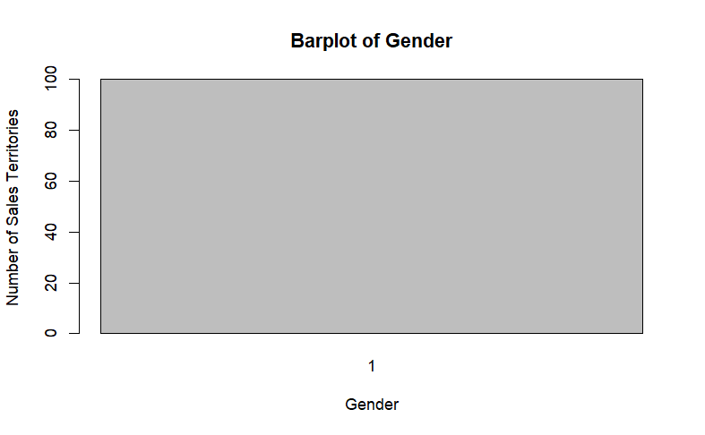

```r
barplot(table(df$gender), main = "Barplot of Gender", xlab = "Gender", ylab = "Number of Sales Territories")
```

Yes, because the summary statistics and the barplot show that the data set only includes `gender = 1`, corresponding to females.

### b)

Do the prices differ across sales territories? (2 points)

#### Solution

```r
summary(df$price)
```

```
   Min. 1st Qu.  Median    Mean 3rd Qu.    Max.
  209.4   271.1   301.4   300.4   329.6   369.4
```

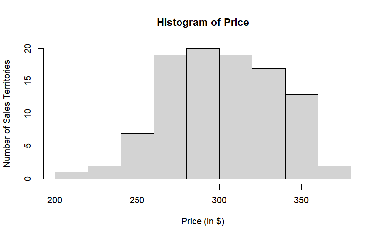

```r
hist(df$price, main = "Histogram of Price", xlab = "Price (in $)", ylab = "Number of Sales Territories")
```

Yes, prices differ across sales territories. For example, the summary statistics exhibit different values for the minimum ($209.4) and maximum ($369.4). Additionally, the histogram shows that prices vary across sales territories.

### c)

Is the management’s statement regarding the professional experience of their sales representatives correct? (2 points)

#### Solution

*Statement to check: Median experience is 5 years*

```r
median(df$experience)
```

```
[1] 4
```

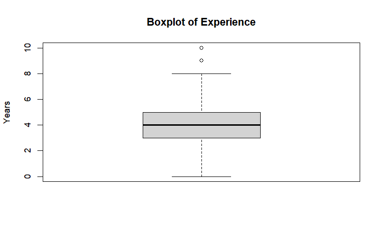

```r
boxplot(df$experience, main = "Boxplot of Experience", ylab = "Years")
```

No, because the summary statistics and the boxplot show that the median of `experience` is 4. If management’s statement (“50% of the sales representatives have at least five years of professional experience in sales”) were true, then the median of `experience` should be 5.

An alternative and equally correct solution is to count the observations that have less than 5 years of experience:

```r
table(df$experience)
```

```
 0  1  2  3  4  5  6  7  8  9 10
 2  9 12 20 19 20  7  6  3  1  1
```

```r
sum(df$experience >= 5) / nrow(df)
```

```
[1] 0.38
```

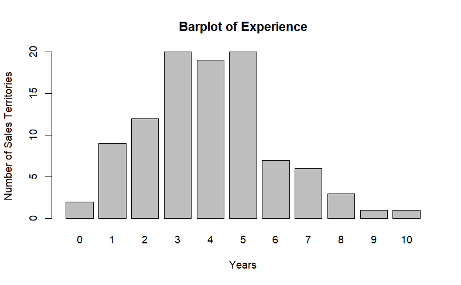

```r
barplot(table(df$experience), main = "Barplot of Experience", xlab = "Years", ylab = "Number of Sales Territories")
```

### d)

Is the management’s statement regarding the background of their sales representatives correct? (2 points)

#### Solution

*Statement to check: At least one-third of sales representatives hold an engineering degree.*

```r
table(df$engineer)
```

```
 No Yes
 72  28
```

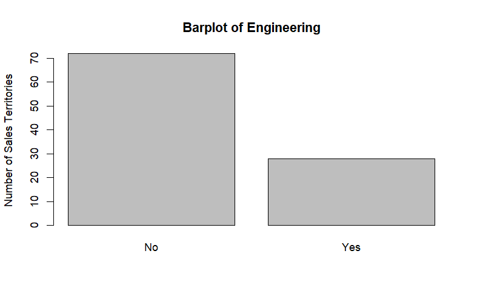

```r
barplot(table(df$engineer), main = "Barplot of Engineering", ylab = "Number of Sales Territories")
```

Management’s statement is incorrect because we only observe that 28 % of sales representatives hold an engineering degree, not at least 33%.

$\frac{28}{72 + 28} = 0.28 < \frac{1}{3} \approx 33\%$.

### e)

Does the advertising agency’s budget differ across the sales territories? (2 points)

#### Solution

```r
summary(df$budget_agency)
```

```
   Min. 1st Qu.  Median    Mean 3rd Qu.    Max.
    329     838    1030    1028    1199    2056
```

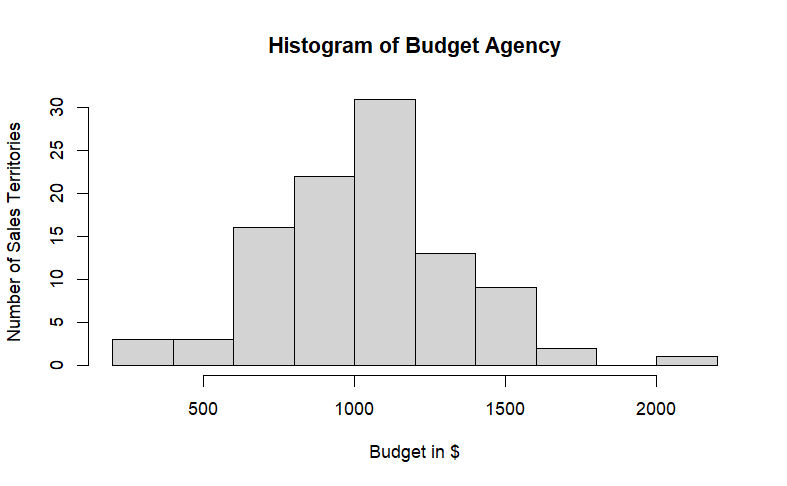

```r
hist(df$budget_agency, main = "Histogram of Budget Agency", xlab = "Budget in $", ylab = "Number of Sales Territories")
```

Yes, the budgets differ. The summary statistics outline that the minimum budget across all sales territories is 329, and the maximum is 2,056. Additionally, the histogram shows that the budget varies strongly across sales territories.

### f)

Did the advertising agency achieve the aim of approximately equally allocating the budget to the two channels (telephone and social media marketing)? (2 points)

#### Solution

```r
cor(df$budget_phone, df$budget_social_media)
```

```
[1] 0.9910698
```

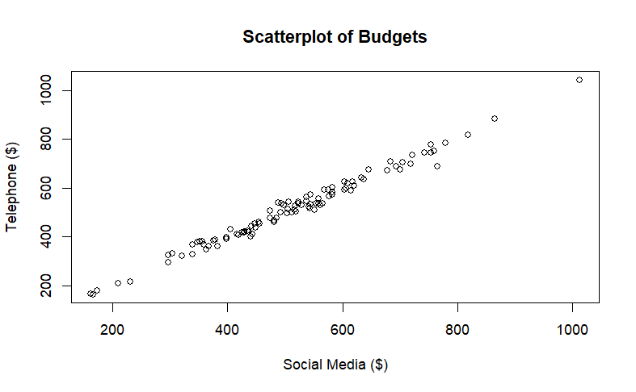

```r
plot(df$budget_social_media, df$budget_phone, main = "Scatterplot of Budgets", xlab = "Social Media ($)", ylab = "Telephone ($)")
```

Yes, all sales territories received almost equal telephone and social media marketing budgets. This insight is easiest to observe in the scatterplot. The visualization displays the almost perfect linear relationship and shows that the social media budget approximately equals the telephone marketing budget. The correlation coefficient is almost 1, and both budgets’ average values are also almost equal.

**Note:** Displaying the individual distributions of the two variables, e.g., via a histogram, is insufficient because a similar distribution of two variables is a necessary but not a sufficient condition for similar budgets in all sales territories.

### g)

Were the sales representatives born in at least 8 different cities? (2 points)

#### Solution

```r
nrow(table(df$location))
```

```
[1] 11
```

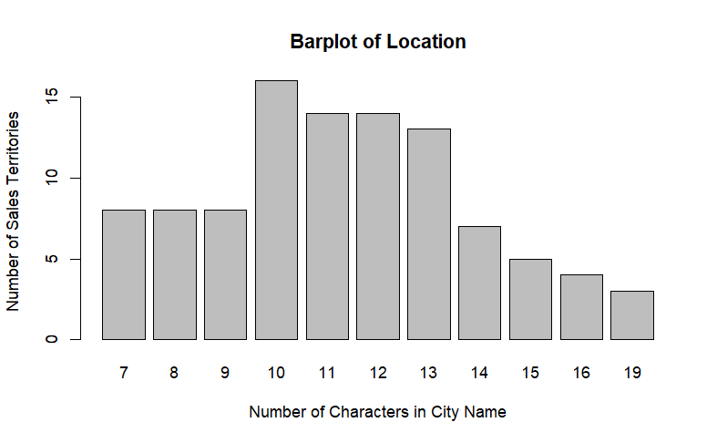

```r
barplot(table(df$location), main = "Barplot of Location", xlab = "Number of Characters in City Name", ylab = "Number of Sales Territories")
```

Yes, because the data set includes 11 different values of `location`, which implies that the sales representatives were born in *at least* 11 cities.

| Step | Task | Max. Points | Achieved Points |
| --- | --- | --- | --- |
| 1-a | Correct vi sualization (1 point), correct non-visual descriptive statistic (1 point). | 2 |  |
| 1-b | see above | 2 |  |
| 1-c | see above | 2 |  |
| 1-d | see above | 2 |  |
| 1-e | see above | 2 |  |
| 1-f | see above | 2 |  |
| 1-g | see above | 2 |  |

## 2) Estimating a Demand Function

Estimate a linear demand function. Justify which variables you include and which ones you ignore. Discuss the influence of price and professional experience on the quantity and how confident you are about their influence. (14 points)

#### Solution

##### **Step 1:** Identify the variables to include in the linear regression equation.

Include all variables except:

- `gender`, because it only has the value 1 and, thus, no variation.
- `location`, because there is no plausible reason why the character length of the sales representative’s city of birth should impact sales.
- `budget_phone` and `budget_social_media`, because
  - the two variables are almost perfectly collinear (50% share each and correlation is almost 1), and
  - the sum of both variables is a linear combination corresponding to the third variable `budget_agency`, leading to perfect multicollinearity: `budget_agency = budget_phone + budget_social_media`.

##### **Step 2: Use a linear regression to estimate** the linear demand function

###### Most Suitable Model

```r
reg_model_1 <- lm(quantity ~ price + experience + engineer + budget_agency, data = df)
```

###### Acceptable Models

```r
reg_model_2 <- lm(quantity ~ price + experience + engineer + budget_phone, data = df)
reg_model_3 <- lm(quantity ~ price + experience + engineer + budget_social_media, data = df)

library(stargazer)
stargazer(reg_model_1, reg_model_2, reg_model_3, type = "text", header = FALSE)
```

```
====================================================================
                                       Dependent variable:
                              --------------------------------------
                                             quantity
                                  (1)          (2)          (3)
--------------------------------------------------------------------
price                          -2.953***    -2.951***    -2.955***
                                (0.038)      (0.038)      (0.038)

experience                      9.039***     9.061***     9.023***
                                (0.663)      (0.659)      (0.669)

engineerYes                      0.954        1.012        0.860
                                (2.972)      (2.956)      (2.990)

budget_agency                   0.023***
                                (0.004)

budget_phone                                 0.046***
                                             (0.009)

budget_social_media                                       0.044***
                                                          (0.009)

Constant                      1,215.966*** 1,215.042*** 1,217.175***
                                (13.124)     (13.090)     (13.161)

--------------------------------------------------------------------
Observations                      100          100          100
R2                               0.985        0.986        0.985
Adjusted R2                      0.985        0.985        0.985
Residual Std. Error (df = 95)    12.868       12.803       12.948
F Statistic (df = 4; 95)      1,609.366*** 1,626.051*** 1,589.121***
====================================================================
Note:                                    *p<0.1; **p<0.05; ***p<0.01
```

###### Incorrect Models

```r
# Including two out of three variables `budget_agency`, `budget_phone`, and `budget_social_media`
reg_model_4 <- lm(quantity ~ price + experience + engineer + budget_phone + budget_social_media,
               data = df)

# Including all three multicollinear independent variables `budget_agency`, `budget_phone`, and `budget_social_media`
reg_model_5 <- lm(quantity ~ price + experience + engineer + budget_agency + budget_phone + budget_social_media,
               data = df)

stargazer(reg_model_4, reg_model_5, type = "text", header = FALSE, column.labels = c("(4)", "(5)"), model.numbers = FALSE)
```

```
==========================================================
                                  Dependent variable:
                              ----------------------------
                                        quantity
                                   (4)            (5)
----------------------------------------------------------
price                           -2.948***      -2.948***
                                 (0.038)        (0.038)

experience                       9.177***      9.177***
                                 (0.665)        (0.665)

engineerYes                       0.943          0.943
                                 (2.950)        (2.950)

budget_agency                                   -0.076
                                                (0.064)

budget_phone                      0.120*         0.196
                                 (0.063)        (0.127)

budget_social_media               -0.076
                                 (0.064)

Constant                       1,214.119***  1,214.119***
                                 (13.085)      (13.085)

----------------------------------------------------------
Observations                       100            100
R2                                0.986          0.986
Adjusted R2                       0.985          0.985
Residual Std. Error (df = 94)     12.775        12.775
F Statistic (df = 5; 94)       1,306.717***  1,306.717***
==========================================================
Note:                          *p<0.1; **p<0.05; ***p<0.01
```

*Notes concerning model selection:*

Model 1 is the preferred model according to the justification from Step 1. In the incorrect model 4, we see the effects of collinearity between the two variables `budget_phone` and `budget_social_media` (as observed through their correlation, which is very close to 1) on the estimated coefficients. The coefficients in model 4 have different signs, even though the overall effect (model 1) and the effect of each variable alone in models 2 and 3 are positive. Additionally, the sum of the coefficients of the variables `budget_phone` and `budget_social_media` in model 4 is similar in magnitude to the total effect, i.e., the coefficient of the variable `budget_agency` in model 1.

##### **Step 3:** Interpretation of Model 1

If the price increases by $1, the (expected) quantity decreases by 2.954 units.

| Step | Task | Max. Points | Achieved Points |
| --- | --- | --- | --- |
| 2-1 | Correct justification of which dependent and independent variables to include in the linear regression. | 6 (6 Points for the correct model. 1 point deduction for each incorrectly included or excluded variable. 0.5 points deduction if the correct decision but not justified.) |  |
| 2-2 | Estimate regression with `lm()` and print `summary()`. | 2 |  |
| 2-3 | Interpret the estimated coefficient of `price` correctly. | 3 (1.5 points for magnitude and statistical s ignificance, each) |  |
| 2-4 | Interpret the estimated coefficient of `experience` correctly. | 3 (1.5 points for magnitude and statistical s ignificance, each) |  |

## 3) Compute Advertising and Price Elasticities of Demand

Use your model to compute the price elasticity of demand and the (advertising) budget elasticity of demand. Interpret these elasticities and assess whether your computed elasticities are consistent with economic intuition. (12 Points)

#### Solution

First, note that elasticities in a linear demand model are not constant. Hence, the elasticity depends on the independent variable’s value. Students must pick a sensible value for both variables to compute the elasticities (advertising budget and price). A good choice would be to select the average values.

```r
elasticity_budget <- coefficients(reg_model_1)["budget_agency"] * mean(df$budget_agency) / mean(df$quantity)
elasticity_budget
```

```
budget_agency
   0.05974684
```

```r
elasticity_price <- coefficients(reg_model_1)["price"] * mean(df$price) / mean(df$quantity)
elasticity_price
```

```
    price
-2.286785
```

Interpretation of the elasticities:

At the average budget, a 1% increase in advertising budget yields a 0.06% increase in demand. Thus, the value of the advertising elasticity is 0.06. A positive advertising elasticity makes economic sense because more advertising should yield higher demand. The value is low but broadly in line with findings from meta-analytical studies (e.g., Sethuraman, Tellis, and Briesch: 0.11)

At the average price, a 1% increase in price yields a 2.29% decrease in demand. So, the value of the price elasticity is ‑2.29. The size of this value is plausible because a higher price yields a lower demand. The value also aligns with findings from meta-analytical studies (e.g., Tellis 1988: -1.76; Bijmolt, Herde, and Pieters 2005: -2.62).

| Step | Task | Max. Points | Achieved Points |
| --- | --- | --- | --- |
| 3-1 | Mentioning that elasticities from a linear demand function are not constant. | 2 |  |
| 3-2 | Sensible choice of values at which to compute the elasticities (e.g., mean, median, profit-maximizing value). | 2 |  |
| 3-3 | Correct computation of the two elasticities. | 4 |  |
| 3-4 | Correct interpretation of the two computed elasticities. | 2 |  |
| 3-4 | Correct evaluation of the two computed elasticities’ plausibility | 2 |  |

## 4) Determine the Optimal Price

A sales representative with three years of professional experience and an engineering degree operates in a sales territory. In addition, the advertising agency spends a budget of $2,000, allocating 50% to telephone and 50% to social media marketing. Determine the optimal price in this setting and explain the steps you take to arrive at your result. Assume fixed costs of zero. What is the contribution margin per unit and the firm’s profit? (20 points)

#### Solution

##### **Step 1:** Write the demand function with regression coefficients from the most preferred model

Notation ($equation$ / `code`):

- $q$ / `q`: quantity sold
- $q_c$ / `q_c`: quantity sold without price term, constant
- $p$ / `p`: price
- $c_v$ / `c_v`: variable costs

$$\hat{q} = \hat{\beta}_0 + \hat{\beta}_1 \cdot p + \hat{\beta}_2 \cdot
experience + \hat{\beta}_3 \cdot engineer +\hat{\beta}_4 \cdot
budget\_agency$$
$$\hat{q} = \hat{q}_c + \hat{\beta}_1 \cdot p$$

where $\hat{q}$ is the (expected value of) quantity.  
$\hat{q}_c$ is the expected quantity without considering the price term:

$$\hat{q}_c = \hat{\beta}_0 +
\hat{\beta}_2 \cdot experience +
\hat{\beta}_3 \cdot engineer +
\hat{\beta}_4 \cdot budget\_agency$$

##### **Step 2:** Compute $\hat{q}_c$, the expected quantity without the impact of the price

```r
coef <- coefficients(reg_model_1)

q_c <- coef["(Intercept)"] + coef["experience"] * 3 + coef["engineerYes"] * 1 + coef["budget_agency"] * 2000
```

##### **Step 3:** Set up the cost and profit functions

*Cost function*

$$c(\hat{q}) = c_v \cdot \hat{q}
= c_v \cdot (\hat{q}_c + \hat{\beta}_1 \cdot p)$$

*Profit function*

$$\pi = p \cdot \hat{q} - c(\hat{q})$$
$$= p \cdot (\hat{q}_c + \hat{\beta}_1 \cdot p) - [c_v \cdot
(\hat{q}_c + \hat{\beta}_1 \cdot p)]$$
$$= p \hat{q}_c + p^2 \hat{\beta}_1 - c_v \hat{q}_c - c_v
\hat{\beta}_1 p$$

##### **Step 4:** Take the first derivative of the profit function with respect to $p$ and set it equal to zero

$$\frac{\partial \pi}{\partial p} = \hat{q}_c + 2p \hat{\beta}_1 -
c_v\hat{\beta}_1 = 0$$

##### **Step 5:** Rearrange the function to get the optimal price $p^*$

$$p^* = \frac{1}{2}(c_v - \frac{\hat{q}_c}{\hat{\beta}_1})$$

##### **Step 6:** Compute the optimal price by inserting the computed values from the above steps

```r
c_v <- 200
```

```r
p_star <- 0.5 * (c_v - (q_c / coef["price"]))
p_star
```

```
(Intercept)
    318.268
```

##### **Step 7:** Compute the profit contribution per unit

```r
profit_contribution_unit <- p_star - c_v
profit_contribution_unit
```

```
(Intercept)
    118.268
```

##### **Step 8:** Compute the (total) profit

```r
q_star <- q_c + coef["price"] * p_star
profit_total <- q_star * profit_contribution_unit
```

The optimal price is $318.27. The profit contribution per unit amounts to $118.27. The firm sells 349 units of the heater fan, yielding a profit of $41305.69.

| Step | Task | Max. Points | Achieved Points |
| --- | --- | --- | --- |
| 4-1 | Description: Set up demand function with regression coefficients. | 2 |  |
| 4-2 | Description: Constant demand $\hat{q}_c$ includes all terms from the regression equation excluding the price term. | 2 |  |
| 4-3 | Description: Set up the profit function and insert the demand function into the profit function. | 2 |  |
| 4-4 | Description: Take the first derivative of the profit function with respect to $p$ and set it equal to zero. | 2 |  |
| 4-5 | Description: Rearrange and solve for the optimal price $p^*$. | 2 |  |
| 4-6 | State the correct formula for the optimal price. | 2 |  |
| 4-7 | Compute the expected quantity (constant) without the price term correctly. | 2 |  |
| 4-8 | Compute the optimal price correctly. | 2 |  |
| 4-9 | Compute the profit contribution per unit correctly. | 2 |  |
| 4-10 | Compute the firm’s profit correctly. | 2 |  |

## 5) Impact of Changes on Optimal Prices

Answer the following two sub-questions by ticking the correct answer.

### a)

How does the optimal price change if a sales representative without an engineering degree works in the sales territory instead of a sales representative with an engineering degree? (2 points)

The optimal price…

- increases
- decreases
- remains about the same
- no statement possible

#### Solution

The optimal price remains about the same.

*Explanation (not required):*

Changes in the regression parameter of `engineerYes` cause a parallel shift of the demand curve (upwards if positive, downwards if negative) or leave the demand curve unaffected if it is statistically insignificantly different from zero.

In our case, the parameter estimate of `engineerYes` is statistically insignificantly different from zero. Hence, we can expect that the demand curve does not change much, implying that the optimal price remains the same.

The following computation of the optimal price for a sales representative without an engineering degree supports this claim:

```r
q_c_no_engineer <- coef["(Intercept)"] + coef["experience"] * 3 + coef["budget_agency"] * 2000
p_star_no_engineer <- 0.5 * (c_v - (q_c_no_engineer / coef["price"]))
```

compared to the optimal price *with* an engineering degree

```r
p_star
```

```
(Intercept)
    318.268
```

```r
p_star_no_engineer
```

```
(Intercept)
   318.1064
```

```r
p_star - p_star_no_engineer
```

```
(Intercept)
  0.1615698
```

The optimal price of a sales representative without an engineering degree is $318.11, and with an engineering degree is $318.27. The price difference is only $0.16.

Conclusion: The magnitude of the difference between the two optimal prices is very small and statistically insignificantly different from zero ($p>0.1$). Hence, the optimal price remains about the same.

### b)

How does the optimal price change if a sales representative with only one year of professional experience works in the sales territory instead of a sales representative with three years of professional experience? (2 points)

The optimal price…

- increases
- decreases
- remains about the same
- no statement possible

#### Solution

The optimal price decreases

*Explanation (not required):*

Similar to the above exercise, we must consider how the demand function changes. The demand function changes significantly because the `experience` regression parameter is statistically significantly positive.

Hence, a decrease in the level of experience from `3` to `1` (`= -2`) years causes a parallel downward shift of the demand function. This change leads to lower demand. Thus, the optimal price decreases.

The following computation of the optimal price with one year of experience supports this claim.

```r
q_c_one_year_experience <- coef["(Intercept)"] + coef["experience"] * 1 + coef["engineerYes"] * 1 +
  coef["budget_agency"] * 2000

p_star_one_year_experience <- 0.5 * (c_v - (q_c_one_year_experience / coef["price"]))
```

compared with the optimal price with three years of experience:

```r
p_star
```

```
(Intercept)
    318.268
```

```r
p_star_one_year_experience
```

```
(Intercept)
   315.2073
```

```r
p_star_one_year_experience - p_star
```

```
(Intercept)
  -3.060719
```

The optimal price of a sales representative with a one-year experience is $315.21, and with a three-year experience, $318.27. The price difference is only $-3.06.

Conclusion: the optimal price decreases by $-3.06, and the coefficient on the variable `experience` is statistically significantly different from zero ($p < 0.01$).

| Step | Task | Max. Points | Achieved Points |
| --- | --- | --- | --- |
| 5-a | Correct answer | 2 |  |
| 5-b | Correct answer | 2 |  |

## 6) Marketing Budget Allocation

The management wants to know whether it should spend the marketing budget on telephone marketing or social media marketing. Which recommendation can you give based on your analyses? (2 points)

#### Solution

In this case, no conclusion is possible because the firm always allocated 50% of the budget to telephone marketing and 50% to social media marketing in each sales territory. Hence, the two budget variables, `budget_phone` and `budget_social_media`, are almost perfectly collinear, making the correct estimation of each variable’s effect on the quantity sold impossible.

| Step | Task | Max. Points | Achieved Points |
| --- | --- | --- | --- |
| 6 | Correct answer | 2 |  |

## 7) Performance and Compensation of Sales Representatives

#### a)

Do female sales representatives sell more than non-female sales representatives? (2 points)

*Answer this question based on your previous results.*

##### Solution

No answer is possible because the data set only includes female sales representatives.

#### b)

Do business outcomes justify paying sales representatives with an engineering degree a higher salary than those without an engineering degree? (2 points)

*Answer this question based on your previous results.*

##### Solution

No, because the expected sold quantity does not differ whether a person holds an engineering degree (see `engineerYes`). While the estimated coefficient is positive, it is not statistically significantly different from zero ($p > 0.1$).

Decrease in estimated sales without an engineering degree:

```r
- coef["engineerYes"]
```

```
engineerYes
 -0.9542576
```

Decrease of profit:

```r
- coef["engineerYes"] * profit_contribution_unit
```

```
engineerYes
  -112.8581
```

The profit decreases by $-112.86. However, this effect is very small compared to the profit of $41305.69. Additionally, the coefficient estimate of `engineerYes` is not statistically significantly different from zero ($p>0.1$).

#### c)

Do business outcomes justify paying sales representatives with more professional experience a higher salary than those with less professional experience? (2 points)

*Answer this question based on your previous results.*

##### Solution

Yes, because the expected quantity increases by 9.04 units for each additional year of experience. The profit contribution per unit is $118.27, so 9.04 additionally sold units increase the profit by $1068.97 (= 9.04 * $118.27). Additionally, the estimated coefficient on the variable `experience` is statistically significantly different from zero ($p<0.01$).

Thus, business outcomes justify a higher salary for more experienced sales representatives.

| Step | Task | Max. Points | Achieved Points |
| --- | --- | --- | --- |
| 7-a | Correct answer, stating that no conclusion is possible. | 2 |  |
| 7-b | Correct answer, including stating that the coefficient is not statistically significantly different from zero. | 2 (0.5 points deduction if no level of significance is defined) |  |
| 7-c | Correct conclusion based on regression estimates. | 2 |  |